# Basic usage

```r
library(devtools)
library(digest)

# devtools::install_github("ipeaGIT/geobr")
library(geobr)
```

The geobr packages downloads the Brazilians shapefiles using simple codes and specific parameters that restricts the desired area. This supports the maps analysis.

## Download shape file

The Brazil is organized into state, mesoregion, microregion and municipalities. The code below download each territoriality.

```r
library(ggplot2)
library(sf)
library(cowplot)
library(sysfonts)
library(grid)
library(beepr)
library(dplyr)
library(readxl)
library(rio)




# download data
y <- 2010
state <- read_state(code_state="all", year=y)
```

## Plot shape file

The codes of territoriality in Brazil is managed by IBGE (Instituto Brasileiro de Geografia e Estatística in portuguese) and can be found [here](https://concla.ibge.gov.br/classificacoes/por-tema/codigo-de-areas/codigo-de-areas).

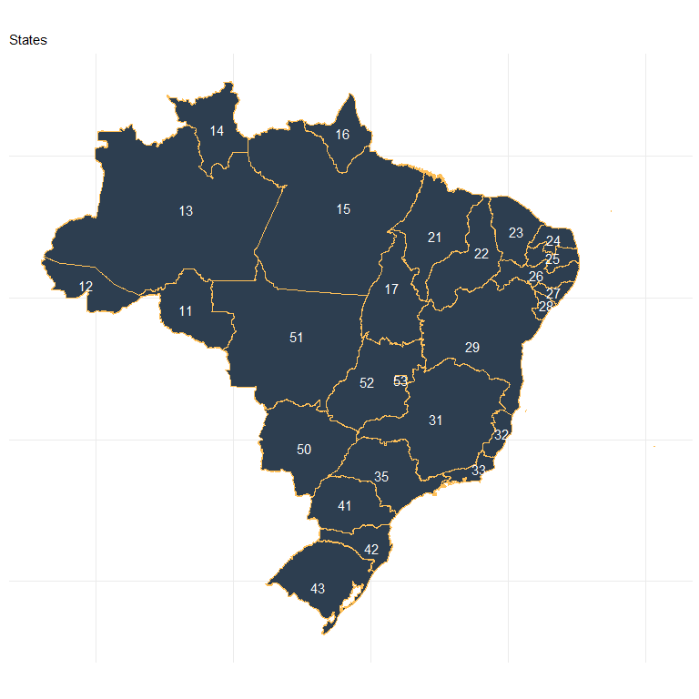

```r
# No plot axis
  no_axis <- theme(axis.title=element_blank(),
                   axis.text=element_blank(),
                   axis.ticks=element_blank())




ggplot() + geom_sf(data=state,
                   fill="#2D3E50",
                   color="#FEBF57", size=.15, show.legend = FALSE) +
    theme_minimal() +
    no_axis +
    labs(subtitle="States", size=8) +
    geom_sf_text(data=state, aes(label = code_state),
                 colour = "white")
```

Filtering the Amazonas state (code 13) we have many mesoregion. The codebelow show this meseregions.

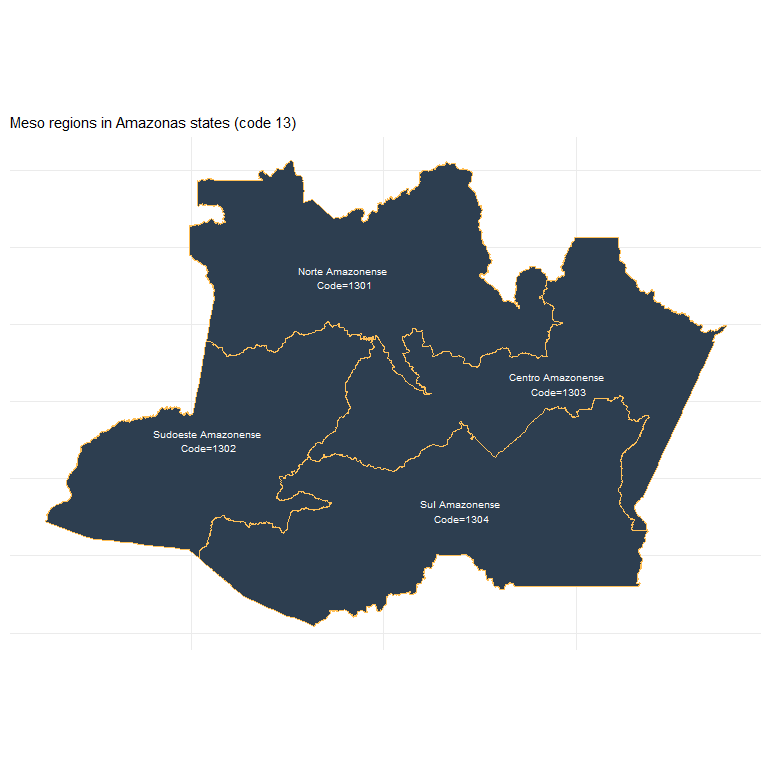

```r
# Meso region download
state_amazonas_meso <- read_meso_region( code_meso = 13, year=y)

# Meso region plot
ggplot() + geom_sf(data=state_amazonas_meso,
                   fill="#2D3E50",
                   color="#FEBF57", size=.15, show.legend = FALSE) +
    theme_minimal() +
    no_axis +
    labs(subtitle="Meso regions in Amazonas states (code 13)", size=8) +
    geom_sf_text(data=state_amazonas_meso, aes(label = paste0(name_meso,"\n Code=",code_meso)),
                 colour = "white",size = 2.6)
```

Filtering the Amazonas state (code 13) we have many microregion. The code below show this microregion.

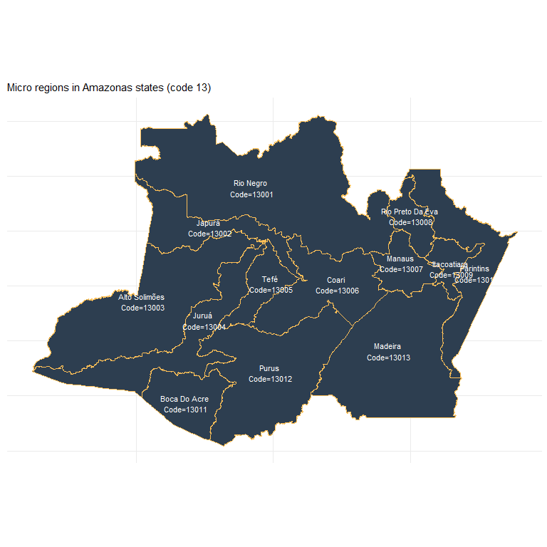

```r
# micro region download
state_amazonas_micro <- read_micro_region( code_micro = 13, year=y)

# micro region plot
ggplot() + geom_sf(data=state_amazonas_micro,
                   fill="#2D3E50",
                   color="#FEBF57", size=.15, show.legend = FALSE) +
    theme_minimal() +
    no_axis +
    labs(subtitle="Micro regions in Amazonas states (code 13)", size=8) +
    geom_sf_text(data=state_amazonas_micro, aes(label = paste0(name_micro ,"\n Code=",code_micro)),
                 colour = "white",size = 2.8)
```

## Merge external data

The shape file could be merged to external data using the key variable that depends of territoriality. In this case we merge the shape data with Human Development Index (HDI) on municipality level of Amazonas state in Brazil. The cities data are avaliable in http://atlasbrasil.org.br/2013/pt/download/.

```r
adh <- rio::import("http://atlasbrasil.org.br/2013/data/rawData/atlas2013_dadosbrutos_pt.xlsx",
                   which = "MUN 91-00-10")


adh <- adh %>%
  dplyr::select(ANO,UF,Codmun7,
         E_ANOSESTUDO,FECTOT,
         RAZDEP,IDHM)

# municipality download
state_amazonas_muni <- read_municipality( code_muni= 13, year=y)
```

```
#> Using data from year 2010
```

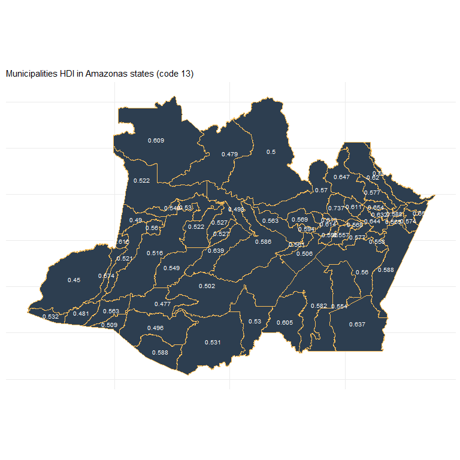

```r
state_amazonas_muni <- state_amazonas_muni %>%
  left_join(adh %>%
              filter(ANO == y) %>%
              select(Codmun7,IDHM), by = c("code_muni" = "Codmun7"))

# municipality plot
ggplot() + geom_sf(data=state_amazonas_muni,
                   fill="#2D3E50",
                   color="#FEBF57", size=.15, show.legend = FALSE) +
    theme_minimal() +
    no_axis +
    labs(subtitle="Municipalities HDI in Amazonas states (code 13)", size=8) +
    geom_sf_text(data=state_amazonas_muni, aes(label = paste0(IDHM)),
                 colour = "white",size = 2.6)
```

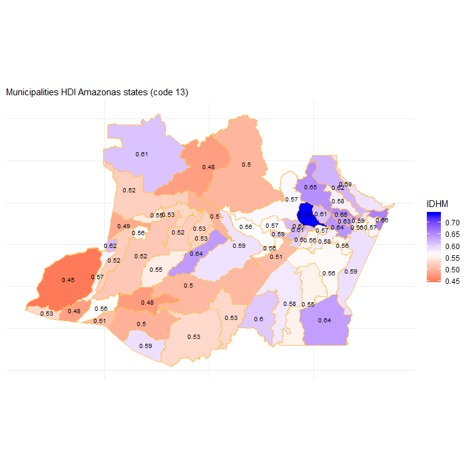

```r
# municipality plot
ggplot() + geom_sf(data=state_amazonas_muni,
                   aes(fill=IDHM),
                   color="#FEBF57", size=.15) +
    theme_minimal() +
    no_axis +
    labs(subtitle="Municipalities HDI Amazonas states (code 13)", size=8) +
    geom_sf_text(data=state_amazonas_muni, aes(label = paste0(round(IDHM,2))),
                 colour = "black",size = 2.6) +
  scale_fill_gradient2( low = "red", mid = "white",
  high = "blue",
  midpoint = mean(state_amazonas_muni$IDHM), ## mean is the midpoint
  space = "Lab",
  na.value = "grey50",
  guide = "colourbar",
  aesthetics = "fill")
```